# PaddleHub 口罩检测示例

如果您想运行本项目，请先右上角fork本项目。

[figure not shown]

防控疫情，众志成城。人工智能技术正被应用到疫情防控中来。

“控制传染源、切断传播途径和排查易感人群”是打赢抗疫的三种手段。

其中切断传播途径中，佩戴口罩已经几乎成为了最重要的举措之一。但是在实际场景中，仍然有不重视、不注意、侥幸心理的人员不戴口罩，尤其在公众场合，给个人和公众造成极大的风险隐患。

目前，仅有少数厂商能够提供口罩佩戴人脸检测AI模型的相关商业化方案，且在密集人流下的识别效果参差不齐。而由于缺乏数据集和模型开发经验，更多中小开放商在面临园区、关口等细分场景时，更是无从下手。

百度积极响应号召，为了助推全社会的力量将AI技术应用于防疫工作，决定免费开源自研的“口罩人脸识别”预训练模型，该模型基于2018年百度在国际顶级计算机视觉会议ECCV 2018的论文PyramidBox而研发，可以在公共场景检测大量的人脸同时，将佩戴口罩和未佩戴口罩的人脸快速识别标注。基于此预训练模型，开发者仅需使用少量自有数据，便可快速完成自有场景模型开发。

飞桨预训练模型管理与迁移学习工具PadddleHub已提供PyramidBox预训练模型(pyramidbox_lite_mobile_mask/pyramidbox_lite_server_mask)用于一键检测人们是否佩戴口罩。同时PaddleHub还提供了飞桨生态下的高质量预训练模型，涵盖了图像分类、目标检测、词法分析、语义模型、情感分析、视频分类、图像生成、图像分割、文本审核、关键点检测等主流模型。更多模型详情请查看官网：https://www.paddlepaddle.org.cn/hub 和 PaddleHub repo：https://github.com/PaddlePaddle/PaddleHub 同时，PaddleHub已和Paddle Lite，Paddle Serving串通，可以将预训练模型直接用于移动端和服务端部署。

通过开源AI模型，百度希望激发广大的开发者和企业厂商（尤其是视频监控），发挥各自的聪明才智，把口罩人脸识别在实际场景中应用起来，更好的做好疫情的防控工作。

本示例利用目标检测轻量化模型pyramidbox_lite_mobile_mask和pyramidbox_lite_server_mask完成佩戴口罩检测。

**NOTE：** 如果您在本地运行该项目示例，需要首先安装PaddleHub。如果您在线运行，需要首先fork该项目示例。之后按照该示例操作即可。

```python
!pip install paddlehub==1.6.2 -i https://pypi.tuna.tsinghua.edu.cn/simple
```

## 一、定义待预测数据

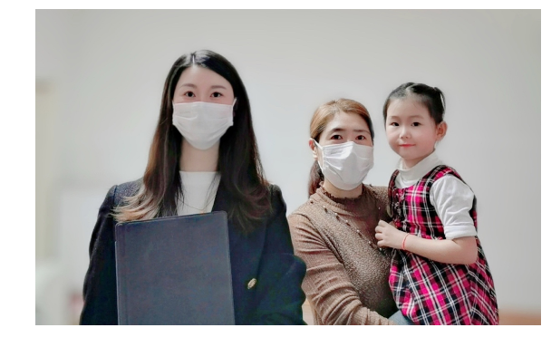

```python
# 待预测图片
test_img_path = ["./test_mask_detection.jpg"]


import matplotlib.pyplot as plt
import matplotlib.image as mpimg

img = mpimg.imread(test_img_path[0])

# 展示待预测图片
plt.figure(figsize=(10,10))
plt.imshow(img)
plt.axis('off')
plt.show()
```

若是待预测图片存放在一个文件中，如左侧文件夹所示的test.txt。每一行是待预测图片的存放路径。

```python
!cat test.txt
```

```
./test_mask_detection.jpg
```

用户想要利用完成对该文件的口罩检测，只需读入该文件，将文件内容存成list，list中每个元素是待预测图片的存放路径。

```python
with open('test.txt', 'r') as f:
    test_img_path=[]
    for line in f:
        test_img_path.append(line.strip())
print(test_img_path)
```

```
['./test_mask_detection.jpg']
```

## 二、加载预训练模型

PaddleHub口罩检测提供了两种预训练模型，[pyramidbox_lite_mobile_mask](https://www.paddlepaddle.org.cn/hubdetail?name=pyramidbox_lite_mobile_mask&en_category=ObjectDetection)和[pyramidbox_lite_server_mask](https://www.paddlepaddle.org.cn/hubdetail?name=pyramidbox_lite_server_mask&en_category=ObjectDetection)。二者均是基于2018年百度发表于计算机视觉顶级会议ECCV 2018的论文PyramidBox而研发的轻量级模型，模型基于主干网络FaceBoxes，对于光照、口罩遮挡、表情变化、尺度变化等常见问题具有很强的鲁棒性。不同点在于，pyramidbox_lite_mobile_mask是针对于移动端优化过的模型，适合部署于移动端或者边缘检测等算力受限的设备上。

```python
import paddlehub as hub

module = hub.Module(name="pyramidbox_lite_mobile_mask")
# module = hub.Module(name="pyramidbox_lite_server_mask")
```

```
[2020-03-23 11:32:52,887] [    INFO] - Installing pyramidbox_lite_mobile_mask module
```

```
Downloading pyramidbox_lite_mobile_mask
[==================================================] 100.00%
Uncompress /home/aistudio/.paddlehub/tmp/tmppyatih_c/pyramidbox_lite_mobile_mask
[==================================================] 100.00%
```

```
[2020-03-23 11:32:54,725] [    INFO] - Successfully installed pyramidbox_lite_mobile_mask-1.2.0
[2020-03-23 11:32:54,808] [    INFO] - Installing pyramidbox_lite_mobile module
```

```
Downloading pyramidbox_lite_mobile
[==================================================] 100.00%
Uncompress /home/aistudio/.paddlehub/tmp/tmpcpsrmm8s/pyramidbox_lite_mobile
[==================================================] 100.00%
```

```
[2020-03-23 11:32:55,152] [    INFO] - Successfully installed pyramidbox_lite_mobile-1.1.1
```

## 三、预测

PaddleHub对于支持一键预测的module，可以调用module的相应预测API，完成预测功能。

```
[2020-03-23 11:32:57,685] [    INFO] - 133 pretrained paramaters loaded by PaddleHub
[2020-03-23 11:32:57,773] [    INFO] - 149 pretrained paramaters loaded by PaddleHub
```

```
image with bbox drawed saved as /home/aistudio/detection_result/test_mask_detection.jpg
{'data': {'label': 'NO MASK', 'left': 1165.2269461650578, 'top': 301.57322066306284, 'right': 1320.4810293648404, 'bottom': 494.4890327521827, 'confidence': 0.99978954}, 'id': 1, 'path': './test_mask_detection.jpg'}
{'data': {'label': 'MASK', 'left': 952.1208348791038, 'top': 352.26076098110997, 'right': 1119.314636084451, 'bottom': 562.4844353590058, 'confidence': 0.97990316}, 'id': 1, 'path': './test_mask_detection.jpg'}
{'data': {'label': 'MASK', 'left': 473.32403670951925, 'top': 212.90940780273172, 'right': 640.6871125257876, 'bottom': 420.9929725513183, 'confidence': 0.9987984}, 'id': 1, 'path': './test_mask_detection.jpg'}
```

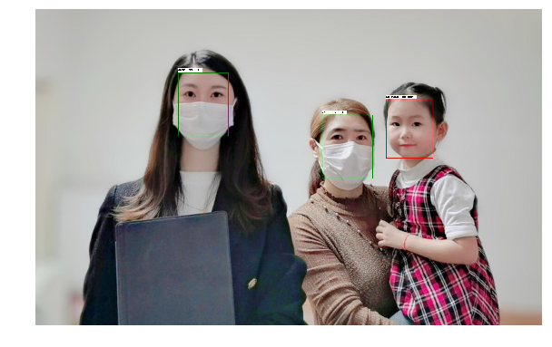

```python
input_dict = {"image": test_img_path}

# 口罩检测预测
results = module.face_detection(data=input_dict, use_multi_scale=True, shrink=0.6,)
for result in results:
    print(result)

# 预测结果展示
img = mpimg.imread("detection_result/test_mask_detection.jpg")
plt.figure(figsize=(10,10))
plt.imshow(img)
plt.axis('off')
plt.show()
```

**如果想要实现通过视频轴帧实时预测，建议先用cv2读入图片帧，之后调用预测接口。本地软件集成可以用这种方式。这样方式也可以加快预测。同时这种方式会直接返回预测结果在图片中的位置，不会将预测结果写入图片。**

代码如下：

```python
import cv2

# 读入图片
test_img_datas = [cv2.imread(img) for img in test_img_path]
# 预测
results = module.face_detection(data={"data":test_img_datas})
for result in results:
    print(result)
```

[output not shown]

```
{'data': {'label': 'MASK', 'left': 457.5789153575897, 'right': 654.8277450799942, 'top': 182.25817680358887, 'bottom': 440.94200134277344, 'confidence': 0.8900112}, 'id': 1}
{'data': {'label': 'MASK', 'left': 945.8848892450333, 'right': 1125.7660418748856, 'top': 340.7917723059654, 'bottom': 578.5958737134933, 'confidence': 0.99627507}, 'id': 1}
{'data': {'label': 'NO MASK', 'left': 1166.5987054109573, 'right': 1323.4498780965805, 'top': 292.07742512226105, 'bottom': 500.40101408958435, 'confidence': 0.9576567}, 'id': 1}
```

其中，label有'MASK'和'NO MASK'两种选择：'MASK'表示戴了口罩，'NO MASK表示没有佩戴口罩。'left'/'rigth'/'top'/'bottom'表示口罩在图片当中的位置。'confidence'表示预测为佩戴口罩'MASK'或者不佩戴口罩'NO MASK'的概率大小。

同时，作为一项完善的开源工作，除了本地推断以外，PaddleHub还支持将该预训练模型部署到服务器或移动设备中。

**由于AIStudio不支持ip访问，以下代码仅做示例，如有需要，请在本地机器运行。**

## 四、部署服务器

借助 PaddleHub，服务器端的部署也非常简单，直接用一条命令行在服务器启动口罩人脸检测与分类模型就行了：

```
$ hub serving start -m pyramidbox_lite_server_mask -p 8866
```

是的，在服务器端这就完全没问题了。相比手动配置各种参数或者调用各种框架，PaddleHub 部署服务器实在是太好用了。

只要在服务器端完成部署，剩下在客户端调用就不会有多大问题了。如下百度展示了调用服务器做推断的示例：制定要预测的图像列表、发出推断请求、返回并保存推断结果。

```
# coding: utf8
import requests
import json
import base64
import os

# 指定要检测的图片并生成列表[("image", img_1), ("image", img_2), ... ]
file_list = ["test.jpg"]
files = [("image", (open(item, "rb"))) for item in file_list]

# 指定检测方法为pyramidbox_lite_server_mask并发送post请求
url = "http://127.0.0.1:8866/predict/image/pyramidbox_lite_server_mask"
r = requests.post(url=url, files=files, data={"visual_result": "True"})

results = eval(r.json()["results"])

# 保存检测生成的图片到output文件夹，打印模型输出结果
if not os.path.exists("output"):
    os.mkdir("output")
for item in results:
    with open(os.path.join("output", item["path"]), "wb") as fp:
        fp.write(base64.b64decode(item["base64"].split(',')[-1]))
        item.pop("base64")
print(json.dumps(results, indent=4, ensure_ascii=False))
```

相信只要有一些 Python 基础，在本地预测、以及部署到服务器端都是没问题的，飞桨的 PaddleHub 已经帮我们做好了各种处理过程。

## 五、移动端部署

Paddle Lite 是飞桨的端侧推理引擎，专门面向移动端的模型推理部署。如果我们需要把口罩人脸检测及分类模型嵌入到手机等移动设备，那么 Paddle Lite 这样的端侧推理引擎能帮我们节省很多工作。

在移动端部署口罩人脸检测及分类模型，也只需要三步：①下载预测库，Paddle Lite 会提供编译好的预测库；②优化模型，使用 model_optimize_tool 工具实现模型优化；③通过预测 API 实现调用。

**Paddle Lite 介绍：https://github.com/PaddlePaddle/Paddle-Lite/**

开发者可以通过PaddleHub下载人脸口罩识别模型。 在正常安装PaddleHub以后，可以通过python执行以下代码下载并保存模型 以下载保存移动端人脸口罩识别模型为例：

```
# coding: utf8
import paddlehub as hub
module = hub.Module(name="pyramidbox_lite_mobile_mask")
# 将模型保存在test_program文件夹之中
module.processor.save_inference_model(dirname="test_program")
```

通过以上代码，可以获得人脸检测和口罩佩戴判断模型，分别存储在test_program 目录下的pyramidbox_lite和mask_detector子文件夹之中。文件夹中的**model**是模型结构文件，**param**文件是权重文件。

其中比较重要的是移动端 API 调用方法，具体实现请参考下文给出的 Paddle Lite 的示例地址。

```
// 读取图片
cv::Mat img = imread(img_path, cv::IMREAD_COLOR);
// 加载人脸检测或者口罩佩戴判别模型
MobileConfig config;
config.set_model_dir(model_dir);
PaddlePredictor* predictor =
      CreatePaddlePredictor<MobileConfig>(config);
// 设置输入
Tensor* input_tensor = predictor->GetInput(0);
input_tensor->Resize({1, 3, img.rows，img.cols});
set_input(img, input_tensor); //调用自定义函数
// 执行
predictor->Run();
// 输出结果
Tensor* output_tensor = predictor->GetOutput(0);
show_output(img, output_tensor); //调用自定义函数
```

人脸识别和佩戴口罩判断在移动端部署的示例地址为： https://github.com/PaddlePaddle/Paddle-Lite/tree/develop/lite/demo/cxx

如您在运行本教程有任何疑问，可以通过以下两种方式提问：

- 进入 飞桨官方技术交流QQ群：79677175 提问
- 通过PaddleHub repo提issue https://github.com/PaddlePaddle/PaddleHub/issues